# Calculation of the Feasible Joint Stiffness

```python
# notebook general configuration
%load_ext autoreload
%autoreload 2

import os
import pickle
import numpy as np
import sympy as sp
from IPython.display import display
sp.interactive.printing.init_printing()
from tqdm import tqdm
import matplotlib.pyplot as plt
plt.rcParams['figure.figsize'] = (10.0, 6.0)
%matplotlib inline
```

```
The autoreload extension is already loaded. To reload it, use:
  %reload_ext autoreload
```

## Subject Data

Please provide the following information for the subject under study:

- **.osim** the scaled OpenSim model (after scaling the model using a static pose)
- **.trc** the marker trajectories of the movement (based on OpenSim file requirements)
- **.mot** the ground reaction forces (based on the OpenSim file format)
- **.xml** describing how to apply the ground reaction forces (based on OpenSim force requirements)
- **heel strike** and **toe off** events (used for annotation of the results, and are not so important)

The following calculations are performed for the *Gait10dof18musc* data set.

```python
# time events of toe off and heel strike
heel_strike_right = [0.65, 1.85]
toe_off_right = [0.15, 1.4]
heel_strike_left = [0.0, 1.25]
toe_off_left = [0.8, 2]

# required files and directories
subject_dir = os.getcwd() + '/../data/gait1018/'
model_file = subject_dir + 'subject01_scaled.osim'
trc_file = subject_dir + 'subject01_walk1.trc'
grf_file = subject_dir + 'subject01_walk1_grf.mot'
grf_xml_file = subject_dir + 'subject01_walk1_grf.xml'
results_dir = os.getcwd() + '/results/'

if not (os.path.isfile(model_file) and
        os.path.isfile(trc_file) and
        os.path.isfile(grf_file) and
        os.path.isfile(grf_xml_file)):
    raise RuntimeError('required files do not exist')

if not os.path.isdir(results_dir):
    raise RuntimeError('required folders do not exist')
```

## Step 1: Perform Required OpenSim Analyses

```python
from opensim_utils import perform_ik, perform_id
from util import plot_sto

# perform OpenSim inverse kinematics
ik_file = perform_ik(model_file, trc_file, results_dir)
plot_sto(ik_file, 2, os.path.join(results_dir, ik_file[0:-4] + '.pdf'))

# perform OpenSim inverse dynamics
id_file = perform_id(model_file, ik_file, grf_file, grf_xml_file, results_dir)
plot_sto(id_file, 2, os.path.join(results_dir, id_file[0:-4] + '.pdf'))

# store file names so that they can be loaded without running this section
with open(results_dir + 'opensim_files.dat', 'wb') as fo:
    pickle.dump((ik_file, id_file), fo)
```

```python
# get file names from step 1
with open(results_dir + 'opensim_files.dat', 'rb') as fo:
    (ik_file, id_file) = pickle.load(fo)
```

## Step 2: Extract Symbolic Moment Arm

Recall that in the definition of joint stiffness the muscle moment arm must be differentiated with respect to the generalized coordinates. Unfortunately, OpenSim lacks the analytical means for evaluating higher order derivatives, as it computes the muscle moment arm numerically from the input joint configuration. In order to derive a symbolic representation, multivariate polynomial fitting was performed on samples of the muscle moment arm at different configurations. To reduce the complexity and improve the robustness of the fit, we determined the coordinates affecting each element in the moment arm matrix, by identifying the DoFs spanned by each muscle.

```python
# since this section of code may be called independently after step 1 ensure
# that cells 2, 5 and 9 are evaluated
from IPython.display import Javascript
Javascript("Jupyter.notebook.execute_cells([2, 5, 9])")
```

```python
from symbolic_moment_arm import calculate_spanning_muscle_coordinates,\
    calculate_moment_arm_symbolically

# calculate the coordinates that are spanned by each muscle (improves
# robustness)
calculate_spanning_muscle_coordinates(model_file, results_dir)

# calculate the symbolic representation of the muscle moment arm matrix
calculate_moment_arm_symbolically(model_file, results_dir)
```

```
To use the future default and silence this warning we advise to pass `rcond=None`, to keep using the old, explicitly pass `rcond=-1`.
  beta = linalg.lstsq(A, y)[0]
```

```
Calculating...
```

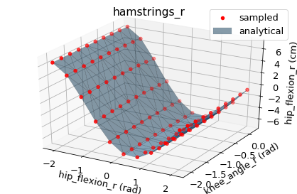

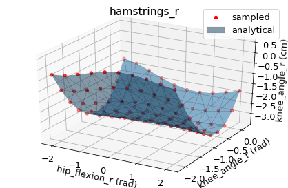

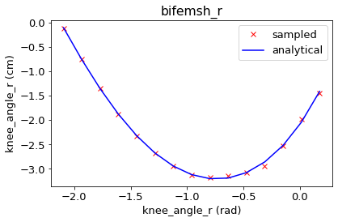

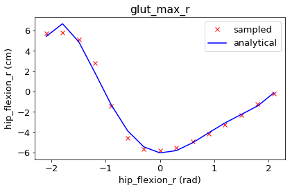

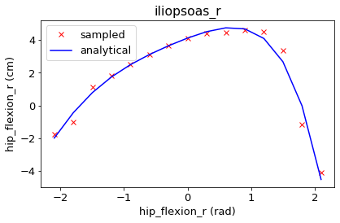

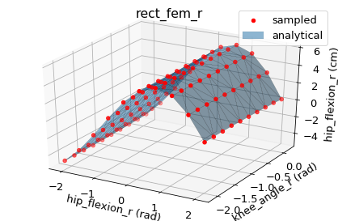

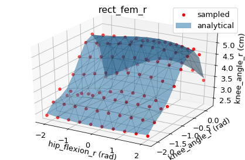

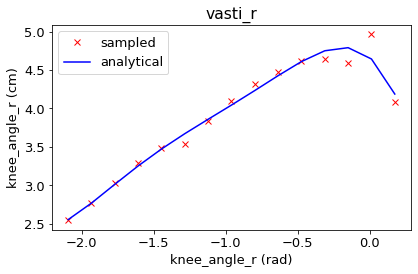

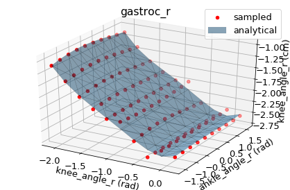

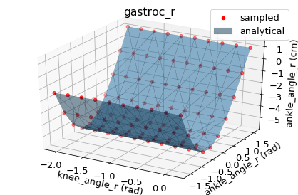

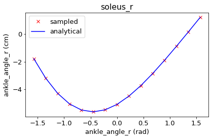

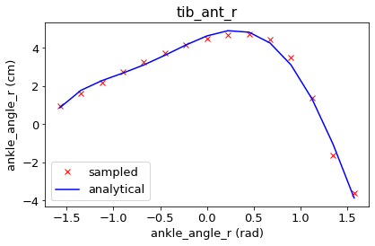

[12 more figures not shown]

```python
from symbolic_moment_arm import visualize_moment_arm
from matplotlib.backends.backend_pdf import PdfPages

# get files from previous step (to avoid recalculation)
with open(results_dir + 'R.dat', 'rb') as f_r,\
     open(results_dir + 'sampling_dict.dat', 'rb') as f_sd,\
     open(results_dir + 'model_coordinates.dat', 'rb') as f_mc,\
     open(results_dir + 'model_muscles.dat', 'rb') as f_mm:
    R = pickle.load(f_r)
    sampling_dict = pickle.load(f_sd)
    model_coordinates = pickle.load(f_mc)
    model_muscles = pickle.load(f_mm)

# visualize 2D and 3D moment arm
with PdfPages(results_dir + 'compare_ma.pdf') as pdf:
    for muscle in sampling_dict.keys():
        coordinates = sampling_dict[muscle]['coordinates']
        if len(coordinates) == 1:
            visualize_moment_arm(coordinates[0], muscle,
                                 coordinates[0],
                                 sampling_dict,
                                 model_coordinates,
                                 model_muscles, R, pdf)
        elif len(coordinates) == 2:
            visualize_moment_arm(coordinates[0], muscle, coordinates,
                                 sampling_dict, model_coordinates,
                                 model_muscles, R, pdf)
            visualize_moment_arm(coordinates[1], muscle, coordinates,
                                 sampling_dict, model_coordinates,
                                 model_muscles, R, pdf)
        else:
            print('only 2D and 3D visualization, skip: ' + muscle)
```

## Step 3: Calculate the Feasible Muscle Forces

The feasible muscle forces are calculated below. Initially, the moment arm and maximum muscle force quantities are computed for each instance of the movement. Then the following inequality is formed assuming a linear muscle model

\begin{equation}\label{equ:linear-muscle-null-space-inequality} \begin{gathered} f_m = f_{max} \circ a_m = f_m^{\parallel} + N_{R} f_{m0},\; 0 \preceq a_m \preceq 1 \rightarrow \\ \begin{bmatrix} - N_{R} \\ \hdashline N_{R} \end{bmatrix} f_{m0} \preceq \begin{bmatrix} f_m^{\parallel} \\ \hdashline f_{max} - f_m^{\parallel} \end{bmatrix} \\ Z f_{m0} \preceq \beta \end{gathered} \end{equation}

where $a_m \in \Re^{m}$ represents a vector of muscle activations, $f_{max} \in \Re^{m}$ a vector specifying the maximum muscle forces, $\circ$ the Hadamard (elementwise) product, $f_m^{\parallel}$ the particular muscle force solution that satisfies the action, $N_{R}$ the moment arm null space and $f_{m0}$ the null space forces.

The next step is to sample the inequality $Z f_{m0} \leq \beta$. This is the bottleneck of the analysis. The *convex_bounded_vertex_enumeration* uses the lsr method, which is a vertex enumeration algorithm for finding the vertices of a polytope in $O(v m^3)$.

```python
# since this section of code may be called independently after step 1 ensure
# that cells 2, 5 and 9 are evaluated
from IPython.display import Javascript
Javascript("Jupyter.notebook.execute_cells([2, 5, 9])")
```

```python
from feasible_muscle_forces import calculate_feasible_muscle_forces

# calculate the feasible muscle forces that satisfy the motion and physiological
# muscle constraints
calculate_feasible_muscle_forces(model_file, ik_file, id_file,
                                 '^pelvis_.*|^lumbar_.*',
                                 'do_not_exclude_any_muscle',
                                 results_dir)
```

```
Calculating moment arm and max force for the whole movement...
```

```
Active id coordinates:  [4, 7, 9, 5, 8, 10]
Active model coordinates:  [3, 4, 5, 6, 7, 8]
Actuve muscles:  [0, 1, 2, 3, 4, 5, 6, 7, 8, 9, 10, 11, 12, 13, 14, 15, 16, 17]
Calculating null space ...
```

## Step 4: Calculate the Feasible Joint Stiffness

In the following section, we will introduce a method for calculating the feasible muscle forces that satisfy the motion and the physiological muscle constraints. As the muscles are the main actors of the system, it is important to examine the effect of muscle redundancy on the calculation of limbs' stiffness.

The muscle stiffness is defined as

\begin{equation}\label{equ:muscle-stiffness} K_m = \frac{\partial f_m}{\partial l_{m}},\; K_m \in \Re^{m \times m} \end{equation}

where $f_m \in \Re^{m}$ represents the muscle forces, $l_{m} \in \Re^{m}$ the musculotendon lengths and $m$ the number of muscles. The joint stiffness is defined as

\begin{equation}\label{equ:joint-stiffness} K_j = \frac{\partial \tau}{\partial q},\; K_j \in \Re^{n \times n} \end{equation}

where $\tau \in \Re^{n}$, $q \in \Re^{n}$ are the generalized forces and coordinates, respectively and $n$ the DoFs of the system. Finally, the task stiffness is defined as

\begin{equation}\label{equ:task-stiffness} K_t = \frac{\partial f_t}{\partial x_t},\; K_t \in \Re^{d \times d} \end{equation}

where $f_t \in \Re^{d}$ denotes the forces, $x_t \in \Re^{d}$ the positions and $d$ the DoFs of the task.

The derivation starts with a model for computing the muscle stiffness matrix $K_m$. The two most adopted approaches are to either use the force-length characteristics of the muscle model or to approximate it using the definition of the short range stiffness, where the latter is shown to explain most of the variance in the experimental measurements. The short range stiffness is proportional to the force developed by the muscle ($f_m$)

\begin{equation}\label{equ:short-range-stiffness} k_{s} = \gamma \frac{f_m}{l_m^o} \end{equation}

where $\gamma = 23.4$ is an experimentally determined constant and $l_m^o$ the optimal muscle length. This definition will be used to populate the diagonal elements of the muscle stiffness matrix, whereas inter-muscle coupling (non-diagonal elements) will be assumed zero since it is difficult to measure and model in practice.

The joint stiffness is related to the muscle stiffness through the following relationship

\begin{equation}\label{equ:joint-muscle-stiffness} K_j = -\frac{\partial R^T}{\partial q} \bullet_2 f_m - R^T K_m R \end{equation}

where the first term captures the varying effect of the muscle moment arm ($R \in \Re^{m \times n}$), while the second term maps the muscle space stiffness to joint space. The notation $\bullet_2$ denotes a product of a rank-3 tensor ($\frac{\partial R^T}{\partial q} \in \Re^{n \times m \times n}$, a 3D matrix) and a rank-1 tensor ($f_m \in \Re^{m}$, a vector), where the index $2$ specifies that the tensor dimensional reduction (by summation) is performed across the second dimension, resulting in a reduced rank-2 tensor of dimensions $n \times n$.

In a similar manner, the task stiffness is related to the muscle stiffness through the following relationship

\begin{equation}\label{equ:task-muscle-stiffness} K_t = -J_t^{+T} \left(\frac{\partial J_t^T}{\partial q} \bullet_2 f_t + \frac{\partial R^T}{\partial q} \bullet_2 f_m + R^T K_m R\right) J_t^{+} \end{equation}

where the task Jacobian matrix ($J_t \in \Re^{d \times n}$) describes the mapping from joint to task space ($\Re^{n} \rightarrow \Re^{d}$), $+$ stands for the Moore-Penrose pseudoinverse and $+T$ the transposed pseudoinverse operator.

Algorithm for calculating the feasible joint stiffness:

**Step 1:** Calculate the feasible muscle forces $f_m^{\oplus}$ that satisfy the task and the physiological muscle constraints

**Step 2:** Calculate the muscle stiffness matrix $K_m$ using the short range stiffness model

\begin{equation*}\label{equ:short-range-stiffness-2} k_s = \gamma \frac{f_m}{l_m^o},\; \gamma = 23.4 \end{equation*}

**Step 3:** Calculate the joint stiffness $K_j$

\begin{equation*} K_j = -\frac{\partial R^T}{\partial q} \bullet_2 f_m - R^T K_m R \end{equation*}

```python
# since this section of code may be called independently after step 3 ensure
# that cells 2, 5 and 9 are evaluated
from IPython.display import Javascript
Javascript("Jupyter.notebook.execute_cells([2, 5, 9])")
```

```python
from feasible_joint_stiffness import calculate_feasible_joint_stiffness

# calculate feasible joint stiffness
calculate_feasible_joint_stiffness(model_file, ik_file, results_dir)
```

```
Initialization ...
```

```
Calculating feasible joint stiffness ...
```

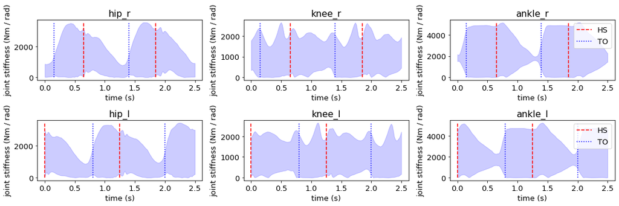

```python
from feasible_joint_stiffness import visualize_feasible_joint_stiffness

# visualize feasible joint stiffness
visualize_feasible_joint_stiffness(results_dir, results_dir)
```

This figure depicts the feasible joint stiffness of the hip, knee and ankle joints during walking with the heel strike and toe-off events annotated accordingly. These results confirm experimental measurements and furthermore present similarities in the outline of the minimum stiffness predicted by our method. Notably, the hip stiffness range is gradually decreasing between heel strike and toe-off, because the flexor muscles are preparing for the swing phase and the capacity to increase the joint stiffness reaches its lowest value before the toe-off event. A similar pattern is observed at the knee joint, which undergoes a flexion and a subsequent extension during the swing phase. The results related to the ankle joint are slightly different from the publication due to a bug in the initial code, which was fixed in this version.